[figure not shown]

# WELCOME!

In this project, you must apply EDA processes for the development of predictive models. Handling outliers, domain knowledge and feature engineering will be challenges.

Also, this project aims to improve your ability to implement algorithms for Multi-Class Classification. Thus, you will have the opportunity to implement many algorithms commonly used for Multi-Class Classification problems.

Before diving into the project, please take a look at the determines and tasks.

# Determines

The 2012 US Army Anthropometric Survey (ANSUR II) was executed by the Natick Soldier Research, Development and Engineering Center (NSRDEC) from October 2010 to April 2012 and is comprised of personnel representing the total US Army force to include the US Army Active Duty, Reserves, and National Guard. In addition to the anthropometric and demographic data described below, the ANSUR II database also consists of 3D whole body, foot, and head scans of Soldier participants. These 3D data are not publicly available out of respect for the privacy of ANSUR II participants. The data from this survey are used for a wide range of equipment design, sizing, and tariffing applications within the military and has many potential commercial, industrial, and academic applications.

The ANSUR II working databases contain 93 anthropometric measurements which were directly measured, and 15 demographic/administrative variables explained below. The ANSUR II Male working database contains a total sample of 4,082 subjects. The ANSUR II Female working database contains a total sample of 1,986 subjects.

DATA DICT: https://data.world/datamil/ansur-ii-data-dictionary/workspace/file?filename=ANSUR+II+Databases+Overview.pdf

To achieve high prediction success, you must understand the data well and develop different approaches that can affect the dependent variable.

Firstly, try to understand the dataset column by column using pandas module. Do research within the scope of domain (body scales, and race characteristics) knowledge on the internet to get to know the data set in the fastest way.

You will implement *Logistic Regression, Support Vector Machine, XGBoost, Random Forest* algorithms. Also, evaluate the success of your models with appropriate performance metrics.

At the end of the project, choose the most successful model and try to enhance the scores with *SMOTE* make it ready to deploy. Furthermore, use *SHAP* to explain how the best model you choose works.

# Tasks

#### 1. Exploratory Data Analysis (EDA)

- Import Libraries, Load Dataset, Exploring Data

  *i. Import Libraries*

  *ii. Ingest Data*

  *iii. Explore Data*

  *iv. Outlier Detection*

  *v. Drop unnecessary features*

#### 2. Data Preprocessing

- Scale (if needed)
- Separete the data frame for evaluation purposes

#### 3. Multi-class Classification

- Import libraries
- Implement SVM Classifer
- Implement Decision Tree Classifier
- Implement Random Forest Classifer
- Implement XGBoost Classifer
- Compare The Models

# EDA

- Drop unnecessary colums
- Drop DODRace class if value count below 500 (we assume that our data model can't learn if it is below 500)

## Import Libraries

Besides Numpy and Pandas, you need to import the necessary modules for data visualization, data preprocessing, Model building and tuning.

*Note: Check out the course materials.*

```python
import pandas as pd
import numpy as np
import requests
import cchardet as chardet
pd.set_option('display.max_columns', None)
pd.set_option('display.max_rows',None)
import matplotlib.pyplot as plt
from ipywidgets import interact
import seaborn as sns
from mlxtend.plotting import plot_confusion_matrix
%matplotlib inline
from sklearn.model_selection import train_test_split
from sklearn.compose import make_column_transformer
from sklearn.preprocessing import OneHotEncoder, OrdinalEncoder, LabelEncoder
from sklearn.preprocessing import StandardScaler, MinMaxScaler, RobustScaler, QuantileTransformer
from sklearn.preprocessing import OneHotEncoder, OrdinalEncoder, LabelEncoder
from category_encoders import BinaryEncoder
from sklearn.compose import make_column_transformer
from sklearn.dummy import DummyClassifier
from sklearn.pipeline import Pipeline, make_pipeline
from sklearn.model_selection import train_test_split
from sklearn.linear_model import LogisticRegression
from sklearn.svm import SVC
from sklearn.ensemble import RandomForestClassifier
import xgboost as xgb
from sklearn.feature_selection import SelectFromModel
from sklearn.model_selection import GridSearchCV, cross_validate, StratifiedKFold
from sklearn.metrics import accuracy_score, confusion_matrix, classification_report, ConfusionMatrixDisplay
from sklearn.metrics import make_scorer
from sklearn.metrics import precision_score, recall_score, accuracy_score, f1_score
from sklearn.metrics import matthews_corrcoef, cohen_kappa_score
from imblearn.over_sampling import SMOTE, BorderlineSMOTE
from imblearn.under_sampling import RandomUnderSampler
from imblearn.pipeline import Pipeline
import shap
from scikitplot.metrics import plot_precision_recall
import warnings
warnings.filterwarnings("ignore")
warnings.warn("this will not show")
import PyPDF2
from sklearn.metrics import average_precision_score
from xgboost import XGBClassifier
```

read the pdf file and get columns name and description

```python
pdf_file = open('ANSUR II Databases Overview.pdf', 'rb')
```

```python
pdf_reader = PyPDF2.PdfReader(pdf_file)
num_pages = len(pdf_reader.pages)
print(len(pdf_reader.pages))
```

```
8
```

```python
dataDescription = pd.DataFrame(columns=['name', 'Description'])
dataDescription
```

|  | name | Description |
| --- | --- | --- |

```python
for i in range (1,6):
    page = pdf_reader.pages[i]
    text = page.extract_text()
    columnPage = text.split('')
    for j in range(1,len(columnPage)):
        index = columnPage[j].split('–')
        index0 = index[0].replace('\n', '').strip()
        index1 = index[1].replace('\n', '').strip()
        dataDescription = dataDescription.append({'name':index0, 'Description':index1}, ignore_index=True)
```

```python
dataDescription.head()
```

|  | name | Description |
| --- | --- | --- |
| 0 | subjectid | A unique number for each participant measured ... |
| 1 | SubjectBirthLocation | Subject Birth Location; a U.S. state or foreig... |
| 2 | SubjectNumericRace | Subject Numeric Race; a single or multi -digit... |
| 3 | Ethnicity | self-reported ethnicity (verified through inte... |
| 4 | DODRace | Department of Defense Race; a single digit ind... |

```python
dataDescription
```

|  | name | Description |
| --- | --- | --- |
| 0 | subjectid | A unique number for each participant measured ... |
| 1 | SubjectBirthLocation | Subject Birth Location; a U.S. state or foreig... |
| 2 | SubjectNumericRace | Subject Numeric Race; a single or multi -digit... |
| 3 | Ethnicity | self-reported ethnicity (verified through inte... |
| 4 | DODRace | Department of Defense Race; a single digit ind... |
| 5 | Gender | “Male” or “Female” |
| 6 | Age | Participant’s age in years |
| 7 | Heightin | Height in Inches; self -reported, comparable t... |
| 8 | Weightlbs | Weight in Pounds; self -reported, comparable t... |
| 9 | WritingPreference | Writing Preference; “Right hand”, “Left hand”,... |
| 10 | Date | Date the participant was measured, ranging fro... |
| 11 | Installation | U.S. Army installation where the measurement o... |
| 12 | Component | “Army National Guard”, “Army Reserve”, or “Reg... |
| 13 | Branch | “Combat Arms”, “Combat Support”, or “Combat Se... |
| 14 | PrimaryMOS | Primary Military Occupational Specialty 5. An... |
| 15 | abdominalextensiondepthsitting | Abdominal Extension Depth, Sitting |
| 16 | acromialheight | Acromial Height |
| 17 | acromionradialelength | Acromion -Radiale Length |
| 18 | anklecircumference | Ankle Circumference |
| 19 | axillaheight | Axilla Height |
| 20 | balloffootcircumference | Ball of Foot Circumference |
| 21 | balloffootlength | Ball of Foot Length |
| 22 | biacromialbreadth | Biacromial Breadth |
| 23 | bicepscircumferenceflexed | Biceps Circumference, Flexed |
| 24 | bicristalbreadth | Bicristal Breadth |
| 25 | bideltoidbreadth | Bideltoid Breadth |
| 26 | bimalleolarbreadth | Bimalleolar Breadth |
| 27 | bitragionchinarc | Bitragion Chin Arc |
| 28 | bitragionsubmandibulararc | Bitragion Submandibular Arc |
| 29 | bizygomaticbreadth | Bizygomatic Breadth |

[output cut: 58 more lines]

## Ingest Data from links below and make a dataframe

- Soldiers Male : https://query.data.world/s/h3pbhckz5ck4rc7qmt2wlknlnn7esr
- Soldiers Female : https://query.data.world/s/sq27zz4hawg32yfxksqwijxmpwmynq

```python
femaleData = pd.read_csv('https://query.data.world/s/sq27zz4hawg32yfxksqwijxmpwmynq')
```

```python
femaleData.head()
```

|  | SubjectId | abdominalextensiondepthsitting | acromialheight | acromionradialelength | anklecircumference | axillaheight | balloffootcircumference | balloffootlength | biacromialbreadth | bicepscircumferenceflexed | bicristalbreadth | bideltoidbreadth | bimalleolarbreadth | bitragionchinarc | bitragionsubmandibulararc | bizygomaticbreadth | buttockcircumference | buttockdepth | buttockheight | buttockkneelength | buttockpopliteallength | calfcircumference | cervicaleheight | chestbreadth | chestcircumference | chestdepth | chestheight | crotchheight | crotchlengthomphalion | … |
| --- | --- | --- | --- | --- | --- | --- | --- | --- | --- | --- | --- | --- | --- | --- | --- | --- | --- | --- | --- | --- | --- | --- | --- | --- | --- | --- | --- | --- | --- | --- |
| 0 | 10037 | 231 | 1282 | 301 | 204 | 1180 | 222 | 177 | 373 | 315 | 263 | 466 | 65 | 338 | 301 | 141 | 1011 | 223 | 836 | 587 | 476 | 360 | 1336 | 274 | 922 | 245 | 1095 | 759 | 557 | … |
| 1 | 10038 | 194 | 1379 | 320 | 207 | 1292 | 225 | 178 | 372 | 272 | 250 | 430 | 64 | 294 | 270 | 126 | 893 | 186 | 900 | 583 | 483 | 350 | 1440 | 261 | 839 | 206 | 1234 | 835 | 549 | … |
| 2 | 10042 | 183 | 1369 | 329 | 233 | 1271 | 237 | 196 | 397 | 300 | 276 | 450 | 69 | 309 | 270 | 128 | 987 | 204 | 861 | 583 | 466 | 384 | 1451 | 287 | 874 | 223 | 1226 | 821 | 643 | … |
| 3 | 10043 | 261 | 1356 | 306 | 214 | 1250 | 240 | 188 | 384 | 364 | 276 | 484 | 68 | 340 | 294 | 144 | 1012 | 253 | 897 | 599 | 471 | 372 | 1430 | 269 | 1008 | 285 | 1170 | 804 | 640 | … |
| 4 | 10051 | 309 | 1303 | 308 | 214 | 1210 | 217 | 182 | 378 | 320 | 336 | 525 | 67 | 300 | 295 | 135 | 1281 | 284 | 811 | 607 | 467 | 433 | 1362 | 305 | 1089 | 290 | 1112 | 726 | 686 | … |

#### When try to read the male data an error appears "'utf-8' codec can't decode byte 0xe9 in position 158656: invalid continuation byte" So we need to know the encoding of file

```python
maleencoding = chardet.detect(requests.get("https://query.data.world/s/h3pbhckz5ck4rc7qmt2wlknlnn7esr").content)['encoding']
maleencoding
```

```
'ISO-8859-2'
```

```python
maleData = pd.read_csv('https://query.data.world/s/h3pbhckz5ck4rc7qmt2wlknlnn7esr', encoding= maleencoding)
```

```python
maleData.head()
```

|  | subjectid | abdominalextensiondepthsitting | acromialheight | acromionradialelength | anklecircumference | axillaheight | balloffootcircumference | balloffootlength | biacromialbreadth | bicepscircumferenceflexed | bicristalbreadth | bideltoidbreadth | bimalleolarbreadth | bitragionchinarc | bitragionsubmandibulararc | bizygomaticbreadth | buttockcircumference | buttockdepth | buttockheight | buttockkneelength | buttockpopliteallength | calfcircumference | cervicaleheight | chestbreadth | chestcircumference | chestdepth | chestheight | crotchheight | crotchlengthomphalion | … |
| --- | --- | --- | --- | --- | --- | --- | --- | --- | --- | --- | --- | --- | --- | --- | --- | --- | --- | --- | --- | --- | --- | --- | --- | --- | --- | --- | --- | --- | --- | --- |
| 0 | 10027 | 266 | 1467 | 337 | 222 | 1347 | 253 | 202 | 401 | 369 | 274 | 493 | 71 | 319 | 291 | 142 | 979 | 240 | 882 | 619 | 509 | 373 | 1535 | 291 | 1074 | 259 | 1292 | 877 | 607 | … |
| 1 | 10032 | 233 | 1395 | 326 | 220 | 1293 | 245 | 193 | 394 | 338 | 257 | 479 | 67 | 344 | 320 | 135 | 944 | 232 | 870 | 584 | 468 | 357 | 1471 | 269 | 1021 | 253 | 1244 | 851 | 615 | … |
| 2 | 10033 | 287 | 1430 | 341 | 230 | 1327 | 256 | 196 | 427 | 408 | 261 | 544 | 75 | 345 | 330 | 135 | 1054 | 258 | 901 | 623 | 506 | 412 | 1501 | 288 | 1120 | 267 | 1288 | 854 | 636 | … |
| 3 | 10092 | 234 | 1347 | 310 | 230 | 1239 | 262 | 199 | 401 | 359 | 262 | 518 | 73 | 328 | 309 | 143 | 991 | 242 | 821 | 560 | 437 | 395 | 1423 | 296 | 1114 | 262 | 1205 | 769 | 590 | … |
| 4 | 10093 | 250 | 1585 | 372 | 247 | 1478 | 267 | 224 | 435 | 356 | 263 | 524 | 80 | 340 | 310 | 138 | 1029 | 275 | 1080 | 706 | 567 | 425 | 1684 | 304 | 1048 | 232 | 1452 | 1014 | 682 | … |

### now will concat the male and female data to become one dataframe

find the difference columns and chake if is just case insensitive rename the columns if not delete it and than concat tham

```python
differencecolumns = maleData.columns.difference(femaleData.columns)
if len (differencecolumns) > 0 :
    differencecolumns1 = femaleData.columns.difference(maleData.columns)
    renamecolumns = []
    for i in range (len (differencecolumns)):
        caseinsensitive = False
        for j in range (len (differencecolumns1)):
            if differencecolumns[i].casefold() == differencecolumns1[j].casefold() :
                maleData.rename(columns={differencecolumns[i]:differencecolumns1[j]},inplace=True)
                caseinsensitive = True
                differencecolumns1 = differencecolumns1.delete(j)
        if caseinsensitive :
            differencecolumns = differencecolumns.delete(i)

    femaleData.drop(differencecolumns1, axis = 1, inplace = True)
    maleData.drop(differencecolumns, axis = 1, inplace = True)
```

```python
allData = pd.concat([femaleData, maleData], axis=0, ignore_index=True)
```

## Explore Data

```python
allData.info()
```

```
<class 'pandas.core.frame.DataFrame'>
RangeIndex: 6068 entries, 0 to 6067
Columns: 108 entries, SubjectId to WritingPreference
dtypes: int64(99), object(9)
memory usage: 5.0+ MB
```

```python
allData.dtypes
```

```
SubjectId                          int64
abdominalextensiondepthsitting     int64
acromialheight                     int64
acromionradialelength              int64
anklecircumference                 int64
axillaheight                       int64
balloffootcircumference            int64
balloffootlength                   int64
biacromialbreadth                  int64
bicepscircumferenceflexed          int64
bicristalbreadth                   int64
bideltoidbreadth                   int64
bimalleolarbreadth                 int64
bitragionchinarc                   int64
bitragionsubmandibulararc          int64
bizygomaticbreadth                 int64
buttockcircumference               int64
buttockdepth                       int64
buttockheight                      int64
buttockkneelength                  int64
buttockpopliteallength             int64
calfcircumference                  int64
cervicaleheight                    int64
chestbreadth                       int64
chestcircumference                 int64
chestdepth                         int64
chestheight                        int64
crotchheight                       int64
crotchlengthomphalion              int64
crotchlengthposterioromphalion     int64
earbreadth                         int64
earlength                          int64
earprotrusion                      int64
elbowrestheight                    int64
eyeheightsitting                   int64
footbreadthhorizontal              int64
footlength                         int64
forearmcenterofgriplength          int64
forearmcircumferenceflexed         int64
forearmforearmbreadth              int64
```

[output cut: 54 more lines]

```
Gender                            object
Date                              object
Installation                      object
Component                         object
Branch                            object
PrimaryMOS                        object
SubjectsBirthLocation             object
SubjectNumericRace                 int64
Ethnicity                         object
DODRace                            int64
Age                                int64
Heightin                           int64
Weightlbs                          int64
WritingPreference                 object
dtype: object
```

```python
allData.head()
```

|  | SubjectId | abdominalextensiondepthsitting | acromialheight | acromionradialelength | anklecircumference | axillaheight | balloffootcircumference | balloffootlength | biacromialbreadth | bicepscircumferenceflexed | bicristalbreadth | bideltoidbreadth | bimalleolarbreadth | bitragionchinarc | bitragionsubmandibulararc | bizygomaticbreadth | buttockcircumference | buttockdepth | buttockheight | buttockkneelength | buttockpopliteallength | calfcircumference | cervicaleheight | chestbreadth | chestcircumference | chestdepth | chestheight | crotchheight | crotchlengthomphalion | … |
| --- | --- | --- | --- | --- | --- | --- | --- | --- | --- | --- | --- | --- | --- | --- | --- | --- | --- | --- | --- | --- | --- | --- | --- | --- | --- | --- | --- | --- | --- | --- |
| 0 | 10037 | 231 | 1282 | 301 | 204 | 1180 | 222 | 177 | 373 | 315 | 263 | 466 | 65 | 338 | 301 | 141 | 1011 | 223 | 836 | 587 | 476 | 360 | 1336 | 274 | 922 | 245 | 1095 | 759 | 557 | … |
| 1 | 10038 | 194 | 1379 | 320 | 207 | 1292 | 225 | 178 | 372 | 272 | 250 | 430 | 64 | 294 | 270 | 126 | 893 | 186 | 900 | 583 | 483 | 350 | 1440 | 261 | 839 | 206 | 1234 | 835 | 549 | … |
| 2 | 10042 | 183 | 1369 | 329 | 233 | 1271 | 237 | 196 | 397 | 300 | 276 | 450 | 69 | 309 | 270 | 128 | 987 | 204 | 861 | 583 | 466 | 384 | 1451 | 287 | 874 | 223 | 1226 | 821 | 643 | … |
| 3 | 10043 | 261 | 1356 | 306 | 214 | 1250 | 240 | 188 | 384 | 364 | 276 | 484 | 68 | 340 | 294 | 144 | 1012 | 253 | 897 | 599 | 471 | 372 | 1430 | 269 | 1008 | 285 | 1170 | 804 | 640 | … |
| 4 | 10051 | 309 | 1303 | 308 | 214 | 1210 | 217 | 182 | 378 | 320 | 336 | 525 | 67 | 300 | 295 | 135 | 1281 | 284 | 811 | 607 | 467 | 433 | 1362 | 305 | 1089 | 290 | 1112 | 726 | 686 | … |

```python
allData.tail()
```

|  | SubjectId | abdominalextensiondepthsitting | acromialheight | acromionradialelength | anklecircumference | axillaheight | balloffootcircumference | balloffootlength | biacromialbreadth | bicepscircumferenceflexed | bicristalbreadth | bideltoidbreadth | bimalleolarbreadth | bitragionchinarc | bitragionsubmandibulararc | bizygomaticbreadth | buttockcircumference | buttockdepth | buttockheight | buttockkneelength | buttockpopliteallength | calfcircumference | cervicaleheight | chestbreadth | chestcircumference | chestdepth | chestheight | crotchheight | crotchlengthomphalion | … |
| --- | --- | --- | --- | --- | --- | --- | --- | --- | --- | --- | --- | --- | --- | --- | --- | --- | --- | --- | --- | --- | --- | --- | --- | --- | --- | --- | --- | --- | --- | --- |
| 6063 | 29442 | 235 | 1353 | 312 | 216 | 1263 | 228 | 193 | 384 | 318 | 241 | 457 | 70 | 321 | 301 | 137 | 917 | 231 | 878 | 587 | 497 | 345 | 1444 | 266 | 954 | 238 | 1231 | 807 | 606 | … |
| 6064 | 29443 | 247 | 1473 | 336 | 234 | 1346 | 253 | 196 | 428 | 374 | 284 | 536 | 76 | 319 | 316 | 135 | 1049 | 252 | 899 | 632 | 517 | 399 | 1533 | 323 | 1072 | 242 | 1301 | 848 | 695 | … |
| 6065 | 29447 | 264 | 1394 | 313 | 227 | 1280 | 245 | 193 | 407 | 367 | 271 | 501 | 74 | 323 | 316 | 142 | 1038 | 276 | 857 | 614 | 502 | 378 | 1469 | 290 | 1045 | 247 | 1263 | 787 | 668 | … |
| 6066 | 29451 | 203 | 1417 | 327 | 223 | 1314 | 250 | 196 | 419 | 365 | 271 | 493 | 75 | 342 | 327 | 138 | 929 | 209 | 898 | 598 | 499 | 389 | 1483 | 284 | 984 | 228 | 1271 | 846 | 603 | … |
| 6067 | 29452 | 327 | 1523 | 358 | 226 | 1408 | 269 | 225 | 442 | 379 | 275 | 531 | 81 | 359 | 364 | 150 | 1009 | 254 | 981 | 659 | 550 | 396 | 1595 | 308 | 1144 | 281 | 1349 | 931 | 637 | … |

```python
allData.sample(10)
```

|  | SubjectId | abdominalextensiondepthsitting | acromialheight | acromionradialelength | anklecircumference | axillaheight | balloffootcircumference | balloffootlength | biacromialbreadth | bicepscircumferenceflexed | bicristalbreadth | bideltoidbreadth | bimalleolarbreadth | bitragionchinarc | bitragionsubmandibulararc | bizygomaticbreadth | buttockcircumference | buttockdepth | buttockheight | buttockkneelength | buttockpopliteallength | calfcircumference | cervicaleheight | chestbreadth | chestcircumference | chestdepth | chestheight | crotchheight | crotchlengthomphalion | … |
| --- | --- | --- | --- | --- | --- | --- | --- | --- | --- | --- | --- | --- | --- | --- | --- | --- | --- | --- | --- | --- | --- | --- | --- | --- | --- | --- | --- | --- | --- | --- |
| 2254 | 11348 | 280 | 1553 | 372 | 242 | 1435 | 270 | 200 | 445 | 394 | 302 | 560 | 75 | 353 | 341 | 155 | 1067 | 264 | 987 | 669 | 535 | 433 | 1639 | 306 | 1182 | 287 | 1401 | 899 | 723 | … |
| 801 | 18403 | 228 | 1315 | 306 | 204 | 1224 | 216 | 176 | 334 | 290 | 230 | 430 | 60 | 310 | 292 | 123 | 1010 | 244 | 864 | 621 | 514 | 355 | 1368 | 250 | 869 | 233 | 1174 | 818 | 618 | … |
| 3665 | 15919 | 201 | 1479 | 346 | 220 | 1375 | 251 | 200 | 409 | 305 | 256 | 477 | 78 | 317 | 302 | 140 | 922 | 226 | 880 | 608 | 500 | 375 | 1542 | 285 | 995 | 235 | 1303 | 861 | 574 | … |
| 5259 | 27764 | 203 | 1364 | 320 | 215 | 1248 | 232 | 184 | 410 | 326 | 261 | 473 | 72 | 318 | 306 | 136 | 936 | 195 | 848 | 586 | 486 | 360 | 1444 | 279 | 987 | 233 | 1218 | 805 | 533 | … |
| 280 | 15009 | 229 | 1315 | 296 | 210 | 1229 | 249 | 182 | 366 | 312 | 293 | 438 | 66 | 315 | 280 | 140 | 1006 | 229 | 858 | 578 | 469 | 342 | 1397 | 262 | 908 | 229 | 1185 | 772 | 542 | … |
| 2239 | 11302 | 252 | 1416 | 332 | 217 | 1305 | 241 | 186 | 402 | 319 | 291 | 489 | 71 | 307 | 299 | 141 | 973 | 232 | 898 | 609 | 502 | 390 | 1493 | 270 | 1031 | 253 | 1285 | 837 | 651 | … |
| 3281 | 14918 | 280 | 1506 | 357 | 224 | 1383 | 260 | 203 | 420 | 365 | 303 | 520 | 67 | 333 | 318 | 147 | 1032 | 248 | 925 | 640 | 528 | 375 | 1581 | 332 | 1117 | 258 | 1305 | 892 | 644 | … |
| 4966 | 27160 | 275 | 1509 | 343 | 243 | 1412 | 266 | 222 | 434 | 404 | 289 | 520 | 81 | 346 | 331 | 148 | 1084 | 275 | 946 | 665 | 531 | 427 | 1620 | 284 | 1101 | 284 | 1369 | 914 | 657 | … |
| 2950 | 14114 | 313 | 1313 | 287 | 246 | 1182 | 267 | 194 | 413 | 388 | 283 | 533 | 78 | 345 | 335 | 152 | 1157 | 289 | 775 | 584 | 459 | 437 | 1404 | 308 | 1137 | 268 | 1163 | 720 | 686 | … |
| 771 | 18342 | 230 | 1353 | 322 | 231 | 1265 | 228 | 192 | 406 | 330 | 286 | 496 | 70 | 311 | 288 | 132 | 1078 | 249 | 864 | 613 | 507 | 393 | 1417 | 296 | 1052 | 253 | 1178 | 803 | 674 | … |

```python
allData.shape
```

```
(6068, 108)
```

```python
allData.duplicated().sum()
```

```
0
```

```python
allData.isnull().sum().sum()
```

```
4647
```

```python
for i in allData.columns :
    if (len(allData[i]) * 0.25 ) <= (allData[i].isnull().sum()) :
        allData.drop(i, axis = 1, inplace = True)
allData = allData[~allData.isnull().any(axis=1)]
```

```python
allData.isnull().sum().sum()
```

```
0
```

```python
datadescribe = allData.describe().T
datadescribe
```

|  | count | mean | std | min | 25% | 50% | 75% | max |
| --- | --- | --- | --- | --- | --- | --- | --- | --- |
| SubjectId | 6068.0 | 20757.198418 | 13159.390894 | 10027.0 | 14841.75 | 20063.5 | 27234.50 | 920103.0 |
| abdominalextensiondepthsitting | 6068.0 | 246.468688 | 37.400106 | 155.0 | 219.00 | 242.0 | 271.00 | 451.0 |
| acromialheight | 6068.0 | 1406.161338 | 79.091048 | 1115.0 | 1350.00 | 1410.0 | 1462.00 | 1683.0 |
| acromionradialelength | 6068.0 | 327.374423 | 20.720018 | 249.0 | 313.00 | 328.0 | 341.25 | 393.0 |
| anklecircumference | 6068.0 | 224.891397 | 16.051833 | 156.0 | 214.00 | 225.0 | 235.00 | 293.0 |
| axillaheight | 6068.0 | 1299.608767 | 72.022286 | 1038.0 | 1249.00 | 1302.0 | 1349.00 | 1553.0 |
| balloffootcircumference | 6068.0 | 244.192650 | 16.845020 | 186.0 | 232.00 | 245.0 | 256.00 | 306.0 |
| balloffootlength | 6068.0 | 194.754614 | 13.516368 | 151.0 | 185.00 | 195.0 | 204.00 | 245.0 |
| biacromialbreadth | 6068.0 | 399.204186 | 30.236914 | 283.0 | 376.00 | 404.0 | 421.00 | 489.0 |
| bicepscircumferenceflexed | 6068.0 | 340.934245 | 41.519866 | 216.0 | 311.00 | 341.0 | 370.00 | 490.0 |
| bicristalbreadth | 6068.0 | 274.735003 | 19.221034 | 197.0 | 262.00 | 274.0 | 288.00 | 362.0 |
| bideltoidbreadth | 6068.0 | 490.754450 | 42.135535 | 357.0 | 460.00 | 492.0 | 520.00 | 637.0 |
| bimalleolarbreadth | 6068.0 | 72.252637 | 5.344590 | 55.0 | 68.00 | 72.0 | 76.00 | 91.0 |
| bitragionchinarc | 6068.0 | 324.896506 | 17.087501 | 267.0 | 314.00 | 326.0 | 336.00 | 385.0 |
| bitragionsubmandibulararc | 6068.0 | 306.636124 | 20.794166 | 245.0 | 292.00 | 307.0 | 321.00 | 390.0 |
| bizygomaticbreadth | 6068.0 | 139.723467 | 7.308457 | 116.0 | 135.00 | 140.0 | 145.00 | 174.0 |
| buttockcircumference | 6068.0 | 1020.084707 | 76.422643 | 737.0 | 968.00 | 1017.0 | 1068.00 | 1341.0 |
| buttockdepth | 6068.0 | 241.619974 | 26.482986 | 168.0 | 222.00 | 241.0 | 259.00 | 349.0 |
| buttockheight | 6068.0 | 870.152274 | 54.822574 | 656.0 | 832.00 | 868.0 | 906.25 | 1080.0 |
| buttockkneelength | 6068.0 | 608.999176 | 33.792839 | 466.0 | 586.00 | 609.0 | 632.00 | 736.0 |
| buttockpopliteallength | 6068.0 | 497.097561 | 29.082390 | 367.0 | 477.00 | 497.0 | 517.00 | 605.0 |
| calfcircumference | 6068.0 | 386.041200 | 30.647180 | 266.0 | 364.75 | 385.0 | 406.00 | 523.0 |
| cervicaleheight | 6068.0 | 1477.490442 | 84.323707 | 1184.0 | 1418.00 | 1484.0 | 1537.00 | 1738.0 |
| chestbreadth | 6068.0 | 282.859097 | 20.659397 | 213.0 | 268.00 | 283.0 | 297.00 | 363.0 |
| chestcircumference | 6068.0 | 1022.098879 | 100.671751 | 695.0 | 949.00 | 1020.5 | 1092.00 | 1469.0 |
| chestdepth | 6068.0 | 251.738464 | 26.777843 | 170.0 | 233.00 | 251.0 | 270.00 | 383.0 |
| chestheight | 6068.0 | 1252.013184 | 79.583972 | 984.0 | 1196.00 | 1259.0 | 1309.00 | 1506.0 |
| crotchheight | 6068.0 | 825.110086 | 54.748240 | 610.0 | 787.00 | 825.0 | 863.00 | 1031.0 |
| crotchlengthomphalion | 6068.0 | 621.851681 | 45.332961 | 473.0 | 590.00 | 620.0 | 651.00 | 799.0 |
| crotchlengthposterioromphalion | 6068.0 | 351.315920 | 29.944868 | 243.0 | 330.00 | 350.0 | 372.00 | 468.0 |

[output cut: 69 more lines]

```python
allData.describe(include=['object'], exclude=['int64']).T
```

|  | count | unique | top | freq |
| --- | --- | --- | --- | --- |
| Gender | 6068 | 2 | Male | 4082 |
| Date | 6068 | 253 | 27-Feb-12 | 45 |
| Installation | 6068 | 12 | Camp Shelby | 1160 |
| Component | 6068 | 3 | Regular Army | 3140 |
| Branch | 6068 | 3 | Combat Service Support | 3174 |
| PrimaryMOS | 6068 | 285 | 11B | 671 |
| SubjectsBirthLocation | 6068 | 152 | California | 446 |
| WritingPreference | 6068 | 3 | Right hand | 5350 |

```python
numberRow = datadescribe.index.tolist()
numberRow
```

```
['SubjectId',
 'abdominalextensiondepthsitting',
 'acromialheight',
 'acromionradialelength',
 'anklecircumference',
 'axillaheight',
 'balloffootcircumference',
 'balloffootlength',
 'biacromialbreadth',
 'bicepscircumferenceflexed',
 'bicristalbreadth',
 'bideltoidbreadth',
 'bimalleolarbreadth',
 'bitragionchinarc',
 'bitragionsubmandibulararc',
 'bizygomaticbreadth',
 'buttockcircumference',
 'buttockdepth',
 'buttockheight',
 'buttockkneelength',
 'buttockpopliteallength',
 'calfcircumference',
 'cervicaleheight',
 'chestbreadth',
 'chestcircumference',
 'chestdepth',
 'chestheight',
 'crotchheight',
 'crotchlengthomphalion',
 'crotchlengthposterioromphalion',
 'earbreadth',
 'earlength',
 'earprotrusion',
 'elbowrestheight',
 'eyeheightsitting',
 'footbreadthhorizontal',
 'footlength',
 'forearmcenterofgriplength',
 'forearmcircumferenceflexed',
 'forearmforearmbreadth',
```

[output cut: 44 more lines]

```
 'verticaltrunkcircumferenceusa',
 'waistbacklength',
 'waistbreadth',
 'waistcircumference',
 'waistdepth',
 'waistfrontlengthsitting',
 'waistheightomphalion',
 'weightkg',
 'wristcircumference',
 'wristheight',
 'SubjectNumericRace',
 'DODRace',
 'Age',
 'Heightin',
 'Weightlbs']
```

```python
allData.shape
```

```
(6068, 107)
```

```python
states_only = ['California', 'New York', 'Texas', 'Indiana', 'Oklahoma', 'Illinois',
          'Florida', 'Minnesota', 'Michigan', 'Mississippi', 'Georgia', 'Alabama',
          'South Carolina', 'North Carolina', 'Ohio', 'Louisiana', 'Pennsylvania',
          'Virginia', 'Massachusetts', 'Wisconsin', 'New Jersey', 'Missouri',
          'Arizona', 'Colorado', 'Maryland', 'Tennessee', 'Kentucky', 'Washington',
          'Kansas', 'South Dakota', 'Iowa', 'Arkansas', 'Oregon', 'Connecticut',
          'Nebraska', 'Hawaii', 'Utah', 'West Virginia', 'Nevada', 'Idaho', 'Rhode Island',
          'Maine', 'North Dakota', 'New Mexico', 'Delaware',
          'New Hampshire', 'Vermont', 'Montana', 'Alaska', 'Wyoming', 'United States']
allData = allData.replace(states_only, 'United States')
```

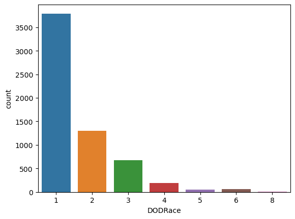

```python
sns.countplot(x = 'DODRace', data = allData);
```

```python
allData['DODRace'] = allData['DODRace']-1
```

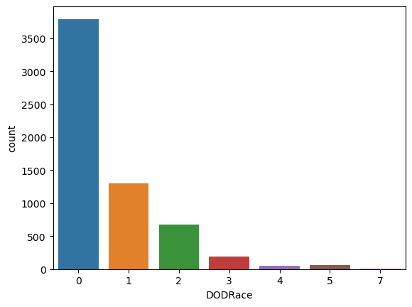

```python
sns.countplot(x = 'DODRace', data = allData);
```

```python
allData = allData[~allData['DODRace'].isin(allData['DODRace'].value_counts()[allData['DODRace'].value_counts()< 500].index)]
```

```python
allData['DODRace'].value_counts()
```

```
0    3792
1    1298
2     679
Name: DODRace, dtype: int64
```

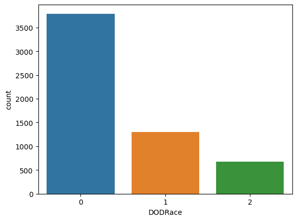

```python
sns.countplot(x = 'DODRace', data = allData);
```

```python
allData.corr(numeric_only=True)["DODRace"].drop("DODRace").sort_values()
```

```
sittingheight                    -0.324329
eyeheightsitting                 -0.319669
wristheight                      -0.267874
stature                          -0.232736
elbowrestheight                  -0.227899
Heightin                         -0.225612
lateralmalleolusheight           -0.218440
acromialheight                   -0.217393
cervicaleheight                  -0.215708
waistbacklength                  -0.208262
axillaheight                     -0.205576
bicristalbreadth                 -0.203874
suprasternaleheight              -0.203790
verticaltrunkcircumferenceusa    -0.196206
chestheight                      -0.193294
shoulderelbowlength              -0.179681
waistheightomphalion             -0.174910
wristcircumference               -0.174408
overheadfingertipreachsitting    -0.169650
waistfrontlengthsitting          -0.160391
handbreadth                      -0.158999
acromionradialelength            -0.158561
tenthribheight                   -0.158044
anklecircumference               -0.157784
chestbreadth                     -0.155248
iliocristaleheight               -0.153345
handcircumference                -0.149810
crotchlengthposterioromphalion   -0.141253
poplitealheight                  -0.132913
waistbreadth                     -0.125099
interscyeii                      -0.123949
functionalleglength              -0.123926
sleevelengthspinewrist           -0.123570
interscyei                       -0.122464
crotchlengthomphalion            -0.117393
kneeheightsitting                -0.116094
neckcircumferencebase            -0.114156
biacromialbreadth                -0.113701
balloffootcircumference          -0.111249
crotchheight                     -0.110503
```

[output cut: 44 more lines]

```
headbreadth                      -0.008958
lowerthighcircumference          -0.003629
buttockdepth                     -0.001344
thighclearance                   -0.000570
palmlength                        0.001644
headcircumference                 0.009739
Age                               0.013222
SubjectNumericRace                0.019567
SubjectId                         0.028524
bizygomaticbreadth                0.032559
thighcircumference                0.032906
bitragionchinarc                  0.083263
heelbreadth                       0.166804
interpupillarybreadth             0.194548
Name: DODRace, dtype: float64
```

```python
less_hundred = allData.SubjectsBirthLocation.value_counts()[allData.SubjectsBirthLocation.value_counts() <= 50].index
```

```python
allData['SubjectsBirthLocation'] = allData['SubjectsBirthLocation'].replace(less_hundred,'other')
```

##### Now, based on the previous analysis and description of each column, we will decide which columns we will delete and which columns the model will work on.

# delete columns

```python
allData.drop(columns=['Date','SubjectId','SubjectNumericRace','Installation','Heightin','Weightlbs','PrimaryMOS'], inplace=True)
```

```python
allData.shape
```

```
(5769, 100)
```

# DATA Preprocessing

- In this step we divide our data to X(Features) and y(Target) then ,
- To train and evaluation purposes we create train and test sets,
- Lastly, scale our data if features not in same scale. Why?

divide our data to X(Features) and y(Target) the Target will be DODRace column and The remaining columns will be Features

```python
x = allData.drop('DODRace',axis=1)
y = allData['DODRace']
```

```python
x.shape
```

```
(5769, 99)
```

```python
x.sample(1)
```

|  | abdominalextensiondepthsitting | acromialheight | acromionradialelength | anklecircumference | axillaheight | balloffootcircumference | balloffootlength | biacromialbreadth | bicepscircumferenceflexed | bicristalbreadth | bideltoidbreadth | bimalleolarbreadth | bitragionchinarc | bitragionsubmandibulararc | bizygomaticbreadth | buttockcircumference | buttockdepth | buttockheight | buttockkneelength | buttockpopliteallength | calfcircumference | cervicaleheight | chestbreadth | chestcircumference | chestdepth | chestheight | crotchheight | crotchlengthomphalion | crotchlengthposterioromphalion | … |
| --- | --- | --- | --- | --- | --- | --- | --- | --- | --- | --- | --- | --- | --- | --- | --- | --- | --- | --- | --- | --- | --- | --- | --- | --- | --- | --- | --- | --- | --- | --- |
| 1098 | 199 | 1302 | 316 | 212 | 1196 | 237 | 164 | 317 | 286 | 249 | 417 | 66 | 307 | 288 | 141 | 1007 | 216 | 798 | 551 | 453 | 368 | 1360 | 233 | 978 | 270 | 1154 | 749 | 625 | 335 | … |

```python
y.shape
```

```
(5769,)
```

```python
y.sample(1)
```

```
3988    0
Name: DODRace, dtype: int64
```

```python
x_train,x_test,y_train,y_test = train_test_split(x,y,test_size=0.2,stratify=y,random_state=42)
```

```python
x_train.shape
```

```
(4615, 99)
```

```python
y_train.shape
```

```
(4615,)
```

```python
x_test.shape
```

```
(1154, 99)
```

```python
y_test.shape
```

```
(1154,)
```

Check which columns are the columns that need to be

```python
allDataobjectdescribe = allData.describe(include=['object'], exclude=['int64']).T
allDataobjectdescribe
```

|  | count | unique | top | freq |
| --- | --- | --- | --- | --- |
| Gender | 5769 | 2 | Male | 3899 |
| Component | 5769 | 3 | Regular Army | 2955 |
| Branch | 5769 | 3 | Combat Service Support | 3021 |
| SubjectsBirthLocation | 5769 | 4 | United States | 5235 |
| WritingPreference | 5769 | 3 | Right hand | 5088 |

```python
columnsName = allDataobjectdescribe.index.tolist()
```

```python
columnsName
```

```
['Gender', 'Component', 'Branch', 'SubjectsBirthLocation', 'WritingPreference']
```

new we will transformer the columns that need to be transformer , i have used ordinal encoder and one-hot encoder

1. the columns i have used the ordinal encoder is:
- gender
- component
- branch
- writingpreference
1. the columns i have used the one-hot encoder is
- subjectsbirthlocation

```python
columnsName.remove('SubjectsBirthLocation')
```

```python
columnsName
```

```
['Gender', 'Component', 'Branch', 'WritingPreference']
```

```python
ordinalCategories = []
for i in columnsName  :
    ordinalCategories.append(allData[i].unique().tolist())
```

```python
ordinalCategories
```

```
[['Female', 'Male'],
 ['Regular Army', 'Army National Guard', 'Army Reserve'],
 ['Combat Support', 'Combat Service Support', 'Combat Arms'],
 ['Right hand', 'Left hand', 'Either hand (No preference)']]
```

```python
columnTransformer = make_column_transformer(
( OneHotEncoder(), ['SubjectsBirthLocation'] ),
( OrdinalEncoder(categories= ordinalCategories), columnsName ),
remainder = 'passthrough'
)
```

```python
columnsName
```

```
['Gender', 'Component', 'Branch', 'WritingPreference']
```

# Modelling

- Fit the model with train dataset
- Get predict from vanilla model on both train and test sets to examine if there is over/underfitting
- Apply GridseachCV for both hyperparemeter tuning and sanity test of our model.
- Use hyperparameters that you find from gridsearch and make final prediction and evaluate the result according to chosen metric.

## 1. Logistic model

### Vanilla Logistic Model

```python
def eval_metric(model, X_train, y_train, X_test, y_test):
    y_train_pred = model.predict(X_train)
    y_pred = model.predict(X_test)

    print("Test_Set")
    print(confusion_matrix(y_test, y_pred))
    print(classification_report(y_test, y_pred))
    print()
    print("Train_Set")
    print(confusion_matrix(y_train, y_train_pred))
    print(classification_report(y_train, y_train_pred))
```

```python
operations = [("column_transformer", columnTransformer ), ("scaler", StandardScaler()), ("logistic", LogisticRegression())]

pipe_model = Pipeline(steps=operations)

pipe_model.fit(x_train, y_train)
```

```
Pipeline(steps=[('column_transformer',
                 ColumnTransformer(remainder='passthrough',
                                   transformers=[('onehotencoder',
                                                  OneHotEncoder(),
                                                  ['SubjectsBirthLocation']),
                                                 ('ordinalencoder',
                                                  OrdinalEncoder(categories=[['Female',
                                                                              'Male'],
                                                                             ['Regular '
                                                                              'Army',
                                                                              'Army '
                                                                              'National '
                                                                              'Guard',
                                                                              'Army '
                                                                              'Reserve'],
                                                                             ['Combat '
                                                                              'Support',
                                                                              'Combat '
                                                                              'Service '
                                                                              'Support',
                                                                              'Combat '
                                                                              'Arms'],
                                                                             ['Right '
                                                                              'hand',
                                                                              'Left '
                                                                              'hand',
                                                                              'Either '
                                                                              'hand '
                                                                              '(No '
                                                                              'preference)']]),
                                                  ['Gender', 'Component',
                                                   'Branch',
                                                   'WritingPreference'])])),
                ('scaler', StandardScaler()),
                ('logistic', LogisticRegression())])
```

```python
eval_metric(pipe_model, x_train, y_train, x_test, y_test)
```

```
Test_Set
[[731   8  19]
 [ 24 234   2]
 [ 60  16  60]]
              precision    recall  f1-score   support

           0       0.90      0.96      0.93       758
           1       0.91      0.90      0.90       260
           2       0.74      0.44      0.55       136

    accuracy                           0.89      1154
   macro avg       0.85      0.77      0.80      1154
weighted avg       0.88      0.89      0.88      1154


Train_Set
[[2936   29   69]
 [  54  967   17]
 [ 240   44  259]]
              precision    recall  f1-score   support

           0       0.91      0.97      0.94      3034
           1       0.93      0.93      0.93      1038
           2       0.75      0.48      0.58       543

    accuracy                           0.90      4615
   macro avg       0.86      0.79      0.82      4615
weighted avg       0.90      0.90      0.89      4615
```

```python
scores = cross_validate(pipe_model,
                        x_train,
                        y_train,
                        scoring=['accuracy', 'precision_weighted','recall_weighted','f1_weighted'],
                        cv = 10,
                        return_train_score=True)
df_scores = pd.DataFrame(scores, index = range(1, 11))
df_scores.mean()[2:]
```

```
test_accuracy               0.885807
train_accuracy              0.902396
test_precision_weighted     0.877630
train_precision_weighted    0.896043
test_recall_weighted        0.885807
train_recall_weighted       0.902396
test_f1_weighted            0.877458
train_f1_weighted           0.895179
dtype: float64
```

### Logistic Model GridsearchCV

```python
operations = [("column_transformer", columnTransformer ), ("scaler", StandardScaler()), ("logistic", LogisticRegression())]

pipe_model = Pipeline(steps=operations)
```

```python
pipe_model.get_params()
```

```
{'memory': None,
 'steps': [('column_transformer',
   ColumnTransformer(remainder='passthrough',
                     transformers=[('onehotencoder', OneHotEncoder(),
                                    ['SubjectsBirthLocation']),
                                   ('ordinalencoder',
                                    OrdinalEncoder(categories=[['Female', 'Male'],
                                                               ['Regular Army',
                                                                'Army National '
                                                                'Guard',
                                                                'Army Reserve'],
                                                               ['Combat Support',
                                                                'Combat Service '
                                                                'Support',
                                                                'Combat Arms'],
                                                               ['Right hand',
                                                                'Left hand',
                                                                'Either hand (No '
                                                                'preference)']]),
                                    ['Gender', 'Component', 'Branch',
                                     'WritingPreference'])])),
  ('scaler', StandardScaler()),
  ('logistic', LogisticRegression())],
 'verbose': False,
 'column_transformer': ColumnTransformer(remainder='passthrough',
                   transformers=[('onehotencoder', OneHotEncoder(),
                                  ['SubjectsBirthLocation']),
                                 ('ordinalencoder',
                                  OrdinalEncoder(categories=[['Female', 'Male'],
                                                             ['Regular Army',
                                                              'Army National '
                                                              'Guard',
                                                              'Army Reserve'],
                                                             ['Combat Support',
                                                              'Combat Service '
                                                              'Support',
                                                              'Combat Arms'],
                                                             ['Right hand',
                                                              'Left hand',
                                                              'Either hand (No '
```

[output cut: 50 more lines]

```
 'logistic__C': 1.0,
 'logistic__class_weight': None,
 'logistic__dual': False,
 'logistic__fit_intercept': True,
 'logistic__intercept_scaling': 1,
 'logistic__l1_ratio': None,
 'logistic__max_iter': 100,
 'logistic__multi_class': 'auto',
 'logistic__n_jobs': None,
 'logistic__penalty': 'l2',
 'logistic__random_state': None,
 'logistic__solver': 'lbfgs',
 'logistic__tol': 0.0001,
 'logistic__verbose': 0,
 'logistic__warm_start': False}
```

```python
lr_param_grid = {'logisticregression__C': [0.001, 0.01, 0.1, 1],
              'logisticregression__class_weight': ['balanced', {'White':1,'Hispanic':3.5,'Black':2},
              {'White':1,'Hispanic':4,'Black':2.5}, {'White':1,'Hispanic':4.5,'Black':2}],
              'logisticregression__penalty': ['l1', 'l2'],
              'logisticregression__solver': ['liblinear','sag','saga','newton-cg'],
              }
```

```python
penalty = ["l1", "l2"]
C = [0.01, 0.1, 1, 5]
weight = ['balanced', None]
param_grid = {"logistic__penalty" : penalty,
             "logistic__C" : C,
             "logistic__class_weight": weight}
grid_model = GridSearchCV(pipe_model, param_grid = param_grid, cv=10, n_jobs=-1, return_train_score=True)
grid_model.fit(x_train, y_train)
```

```
GridSearchCV(cv=10,
             estimator=Pipeline(steps=[('column_transformer',
                                        ColumnTransformer(remainder='passthrough',
                                                          transformers=[('onehotencoder',
                                                                         OneHotEncoder(),
                                                                         ['SubjectsBirthLocation']),
                                                                        ('ordinalencoder',
                                                                         OrdinalEncoder(categories=[['Female',
                                                                                                     'Male'],
                                                                                                    ['Regular '
                                                                                                     'Army',
                                                                                                     'Army '
                                                                                                     'National '
                                                                                                     'Guard',
                                                                                                     'Army '
                                                                                                     'Reserve'],
                                                                                                    ['Combat '
                                                                                                     'Support',
                                                                                                     'Combat '
                                                                                                     'Service '
                                                                                                     'Support',
                                                                                                     'Combat '
                                                                                                     'Arms'],
                                                                                                    ['Right '
                                                                                                     'hand',
                                                                                                     'Left '
                                                                                                     'hand',
                                                                                                     'Either '
                                                                                                     'hand '
                                                                                                     '(No '
                                                                                                     'preference)']]),
                                                                         ['Gender',
                                                                          'Component',
                                                                          'Branch',
                                                                          'WritingPreference'])])),
                                       ('scaler', StandardScaler()),
                                       ('logistic', LogisticRegression())]),
             n_jobs=-1,
             param_grid={'logistic__C': [0.01, 0.1, 1, 5],
                         'logistic__class_weight': ['balanced', None],
                         'logistic__penalty': ['l1', 'l2']},
             return_train_score=True)
```

```python
grid_model.best_params_
```

```
{'logistic__C': 0.1, 'logistic__class_weight': None, 'logistic__penalty': 'l2'}
```

```python
grid_model.best_estimator_
```

```
Pipeline(steps=[('column_transformer',
                 ColumnTransformer(remainder='passthrough',
                                   transformers=[('onehotencoder',
                                                  OneHotEncoder(),
                                                  ['SubjectsBirthLocation']),
                                                 ('ordinalencoder',
                                                  OrdinalEncoder(categories=[['Female',
                                                                              'Male'],
                                                                             ['Regular '
                                                                              'Army',
                                                                              'Army '
                                                                              'National '
                                                                              'Guard',
                                                                              'Army '
                                                                              'Reserve'],
                                                                             ['Combat '
                                                                              'Support',
                                                                              'Combat '
                                                                              'Service '
                                                                              'Support',
                                                                              'Combat '
                                                                              'Arms'],
                                                                             ['Right '
                                                                              'hand',
                                                                              'Left '
                                                                              'hand',
                                                                              'Either '
                                                                              'hand '
                                                                              '(No '
                                                                              'preference)']]),
                                                  ['Gender', 'Component',
                                                   'Branch',
                                                   'WritingPreference'])])),
                ('scaler', StandardScaler()),
                ('logistic', LogisticRegression(C=0.1))])
```

```python
eval_metric(grid_model, x_train, y_train, x_test, y_test)
```

```
Test_Set
[[740   3  15]
 [ 21 238   1]
 [ 62  15  59]]
              precision    recall  f1-score   support

           0       0.90      0.98      0.94       758
           1       0.93      0.92      0.92       260
           2       0.79      0.43      0.56       136

    accuracy                           0.90      1154
   macro avg       0.87      0.78      0.81      1154
weighted avg       0.89      0.90      0.89      1154


Train_Set
[[2937   35   62]
 [  69  953   16]
 [ 253   37  253]]
              precision    recall  f1-score   support

           0       0.90      0.97      0.93      3034
           1       0.93      0.92      0.92      1038
           2       0.76      0.47      0.58       543

    accuracy                           0.90      4615
   macro avg       0.87      0.78      0.81      4615
weighted avg       0.89      0.90      0.89      4615
```

```python
pd.DataFrame(grid_model.cv_results_).loc[
    grid_model.best_index_, ["mean_test_score", "mean_train_score"]
]
```

```
mean_test_score     0.889059
mean_train_score    0.899314
Name: 7, dtype: object
```

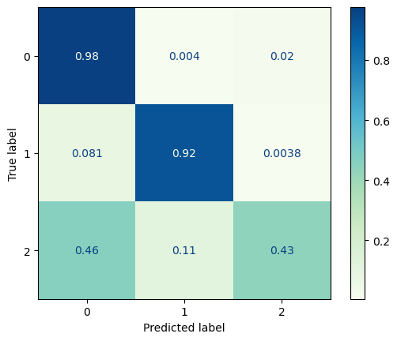

```python
ConfusionMatrixDisplay.from_estimator(grid_model,x_test, y_test,normalize='true', cmap='GnBu');
```

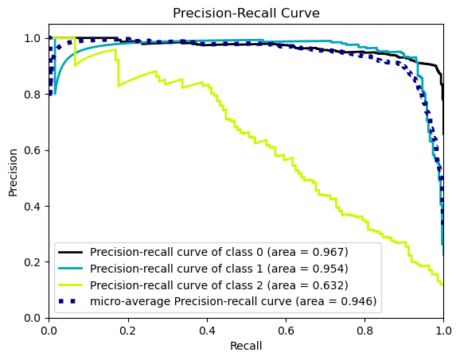

```python
y_pred_proba = grid_model.predict_proba(x_test)

plot_precision_recall(y_test, y_pred_proba)
plt.show();
```

```python
y_pred = grid_model.predict(x_test)
y_test_dummies = pd.get_dummies(y_test).values
log_AP = average_precision_score(y_test_dummies[:, 2], y_pred_proba[:, 2])
log_f1 = f1_score(y_test, y_pred, average=None, labels=[3])
log_recall = recall_score(y_test, y_pred, average=None, labels=[3])
```

## 2. SVC

### Vanilla SVC model

```python
svm = SVC()

svm_pipe = make_pipeline(columnTransformer, MinMaxScaler(), svm)

svm_pipe.fit(x_train, y_train)
```

```
Pipeline(steps=[('columntransformer',
                 ColumnTransformer(remainder='passthrough',
                                   transformers=[('onehotencoder',
                                                  OneHotEncoder(),
                                                  ['SubjectsBirthLocation']),
                                                 ('ordinalencoder',
                                                  OrdinalEncoder(categories=[['Female',
                                                                              'Male'],
                                                                             ['Regular '
                                                                              'Army',
                                                                              'Army '
                                                                              'National '
                                                                              'Guard',
                                                                              'Army '
                                                                              'Reserve'],
                                                                             ['Combat '
                                                                              'Support',
                                                                              'Combat '
                                                                              'Service '
                                                                              'Support',
                                                                              'Combat '
                                                                              'Arms'],
                                                                             ['Right '
                                                                              'hand',
                                                                              'Left '
                                                                              'hand',
                                                                              'Either '
                                                                              'hand '
                                                                              '(No '
                                                                              'preference)']]),
                                                  ['Gender', 'Component',
                                                   'Branch',
                                                   'WritingPreference'])])),
                ('minmaxscaler', MinMaxScaler()), ('svc', SVC())])
```

```python
eval_metric(svm_pipe, x_train, y_train, x_test, y_test)
```

```
Test_Set
[[744   5   9]
 [ 26 232   2]
 [ 82  14  40]]
              precision    recall  f1-score   support

           0       0.87      0.98      0.92       758
           1       0.92      0.89      0.91       260
           2       0.78      0.29      0.43       136

    accuracy                           0.88      1154
   macro avg       0.86      0.72      0.75      1154
weighted avg       0.87      0.88      0.86      1154


Train_Set
[[2990   19   25]
 [  75  958    5]
 [ 348   36  159]]
              precision    recall  f1-score   support

           0       0.88      0.99      0.93      3034
           1       0.95      0.92      0.93      1038
           2       0.84      0.29      0.43       543

    accuracy                           0.89      4615
   macro avg       0.89      0.73      0.77      4615
weighted avg       0.89      0.89      0.87      4615
```

### SVC Model GridsearchCV

```python
svm_pipe.get_params()
```

```
{'memory': None,
 'steps': [('columntransformer',
   ColumnTransformer(remainder='passthrough',
                     transformers=[('onehotencoder', OneHotEncoder(),
                                    ['SubjectsBirthLocation']),
                                   ('ordinalencoder',
                                    OrdinalEncoder(categories=[['Female', 'Male'],
                                                               ['Regular Army',
                                                                'Army National '
                                                                'Guard',
                                                                'Army Reserve'],
                                                               ['Combat Support',
                                                                'Combat Service '
                                                                'Support',
                                                                'Combat Arms'],
                                                               ['Right hand',
                                                                'Left hand',
                                                                'Either hand (No '
                                                                'preference)']]),
                                    ['Gender', 'Component', 'Branch',
                                     'WritingPreference'])])),
  ('minmaxscaler', MinMaxScaler()),
  ('svc', SVC())],
 'verbose': False,
 'columntransformer': ColumnTransformer(remainder='passthrough',
                   transformers=[('onehotencoder', OneHotEncoder(),
                                  ['SubjectsBirthLocation']),
                                 ('ordinalencoder',
                                  OrdinalEncoder(categories=[['Female', 'Male'],
                                                             ['Regular Army',
                                                              'Army National '
                                                              'Guard',
                                                              'Army Reserve'],
                                                             ['Combat Support',
                                                              'Combat Service '
                                                              'Support',
                                                              'Combat Arms'],
                                                             ['Right hand',
                                                              'Left hand',
                                                              'Either hand (No '
```

[output cut: 50 more lines]

```
 'svc__C': 1.0,
 'svc__break_ties': False,
 'svc__cache_size': 200,
 'svc__class_weight': None,
 'svc__coef0': 0.0,
 'svc__decision_function_shape': 'ovr',
 'svc__degree': 3,
 'svc__gamma': 'scale',
 'svc__kernel': 'rbf',
 'svc__max_iter': -1,
 'svc__probability': False,
 'svc__random_state': None,
 'svc__shrinking': True,
 'svc__tol': 0.001,
 'svc__verbose': False}
```

```python
param_grid = {'SVC__C': [0.001, 0.05, 0.01, 0.1],
              'SVC__gamma': ["scale", "auto", 0.2, 0.3],
              'SVC__kernel': ['rbf', 'linear'],
              'SVC__class_weight': ["balanced", None]}
```

```python
operations = [("column_transformer", columnTransformer ), ("scaler", StandardScaler()), ("SVC", SVC(probability=True))]
pipe_model = Pipeline(steps=operations)
svm_model_grid = GridSearchCV(pipe_model,
                              param_grid,
                              scoring="f1_weighted",
                              cv=10,
                              n_jobs=-1,
                              return_train_score=True)
svm_model_grid.fit(x_train, y_train)
```

```
GridSearchCV(cv=10,
             estimator=Pipeline(steps=[('column_transformer',
                                        ColumnTransformer(remainder='passthrough',
                                                          transformers=[('onehotencoder',
                                                                         OneHotEncoder(),
                                                                         ['SubjectsBirthLocation']),
                                                                        ('ordinalencoder',
                                                                         OrdinalEncoder(categories=[['Female',
                                                                                                     'Male'],
                                                                                                    ['Regular '
                                                                                                     'Army',
                                                                                                     'Army '
                                                                                                     'National '
                                                                                                     'Guard',
                                                                                                     'Army '
                                                                                                     'Reserve'],
                                                                                                    ['Combat '
                                                                                                     'Support',
                                                                                                     'Combat '
                                                                                                     'Service '
                                                                                                     'Support',...
                                                                                                     'hand '
                                                                                                     '(No '
                                                                                                     'preference)']]),
                                                                         ['Gender',
                                                                          'Component',
                                                                          'Branch',
                                                                          'WritingPreference'])])),
                                       ('scaler', StandardScaler()),
                                       ('SVC', SVC(probability=True))]),
             n_jobs=-1,
             param_grid={'SVC__C': [0.001, 0.05, 0.01, 0.1],
                         'SVC__class_weight': ['balanced', None],
                         'SVC__gamma': ['scale', 'auto', 0.2, 0.3],
                         'SVC__kernel': ['rbf', 'linear']},
             return_train_score=True, scoring='f1_weighted')
```

```python
svm_model_grid.best_params_
```

```
{'SVC__C': 0.1,
 'SVC__class_weight': None,
 'SVC__gamma': 'scale',
 'SVC__kernel': 'linear'}
```

```python
pd.DataFrame(svm_model_grid.cv_results_).loc[svm_model_grid.best_index_, ["mean_test_score", "mean_train_score"]]
```

```
mean_test_score     0.877478
mean_train_score    0.890346
Name: 57, dtype: object
```

```python
eval_metric(svm_model_grid, x_train, y_train, x_test, y_test)
```

```
Test_Set
[[745   4   9]
 [ 20 238   2]
 [ 65  11  60]]
              precision    recall  f1-score   support

           0       0.90      0.98      0.94       758
           1       0.94      0.92      0.93       260
           2       0.85      0.44      0.58       136

    accuracy                           0.90      1154
   macro avg       0.89      0.78      0.82      1154
weighted avg       0.90      0.90      0.89      1154


Train_Set
[[2945   39   50]
 [  64  960   14]
 [ 257   40  246]]
              precision    recall  f1-score   support

           0       0.90      0.97      0.93      3034
           1       0.92      0.92      0.92      1038
           2       0.79      0.45      0.58       543

    accuracy                           0.90      4615
   macro avg       0.87      0.78      0.81      4615
weighted avg       0.89      0.90      0.89      4615
```

```python
y_pred = svm_model_grid.predict(x_test)
y_test_dummies = pd.get_dummies(y_test).values
svm_AP = average_precision_score(y_test_dummies[:, 2], y_pred_proba[:, 2])
svm_f1 = f1_score(y_test, y_pred, average=None, labels=[3])
svm_recall = recall_score(y_test, y_pred, average=None, labels=[3])
```

## 3. RF

### Vanilla RF Model

```python
operations = [("column_transformer", columnTransformer ), ("random", RandomForestClassifier(random_state=101))]
pipe_model = Pipeline(steps=operations)
pipe_model.fit(x_train, y_train)
eval_metric(pipe_model, x_train, y_train, x_test, y_test)
```

```
Test_Set
[[741  13   4]
 [ 58 201   1]
 [101  15  20]]
              precision    recall  f1-score   support

           0       0.82      0.98      0.89       758
           1       0.88      0.77      0.82       260
           2       0.80      0.15      0.25       136

    accuracy                           0.83      1154
   macro avg       0.83      0.63      0.65      1154
weighted avg       0.83      0.83      0.80      1154


Train_Set
[[3034    0    0]
 [   0 1038    0]
 [   0    0  543]]
              precision    recall  f1-score   support

           0       1.00      1.00      1.00      3034
           1       1.00      1.00      1.00      1038
           2       1.00      1.00      1.00       543

    accuracy                           1.00      4615
   macro avg       1.00      1.00      1.00      4615
weighted avg       1.00      1.00      1.00      4615
```

### RF Model GridsearchCV

```python
pipe_model.get_params()
```

```
{'memory': None,
 'steps': [('column_transformer',
   ColumnTransformer(remainder='passthrough',
                     transformers=[('onehotencoder', OneHotEncoder(),
                                    ['SubjectsBirthLocation']),
                                   ('ordinalencoder',
                                    OrdinalEncoder(categories=[['Female', 'Male'],
                                                               ['Regular Army',
                                                                'Army National '
                                                                'Guard',
                                                                'Army Reserve'],
                                                               ['Combat Support',
                                                                'Combat Service '
                                                                'Support',
                                                                'Combat Arms'],
                                                               ['Right hand',
                                                                'Left hand',
                                                                'Either hand (No '
                                                                'preference)']]),
                                    ['Gender', 'Component', 'Branch',
                                     'WritingPreference'])])),
  ('random', RandomForestClassifier(random_state=101))],
 'verbose': False,
 'column_transformer': ColumnTransformer(remainder='passthrough',
                   transformers=[('onehotencoder', OneHotEncoder(),
                                  ['SubjectsBirthLocation']),
                                 ('ordinalencoder',
                                  OrdinalEncoder(categories=[['Female', 'Male'],
                                                             ['Regular Army',
                                                              'Army National '
                                                              'Guard',
                                                              'Army Reserve'],
                                                             ['Combat Support',
                                                              'Combat Service '
                                                              'Support',
                                                              'Combat Arms'],
                                                             ['Right hand',
                                                              'Left hand',
                                                              'Either hand (No '
                                                              'preference)']]),
```

[output cut: 48 more lines]

```
 'random__criterion': 'gini',
 'random__max_depth': None,
 'random__max_features': 'sqrt',
 'random__max_leaf_nodes': None,
 'random__max_samples': None,
 'random__min_impurity_decrease': 0.0,
 'random__min_samples_leaf': 1,
 'random__min_samples_split': 2,
 'random__min_weight_fraction_leaf': 0.0,
 'random__n_estimators': 100,
 'random__n_jobs': None,
 'random__oob_score': False,
 'random__random_state': 101,
 'random__verbose': 0,
 'random__warm_start': False}
```

```python
param_grid = {
    "RF_model__n_estimators": [400, 500],
    "RF_model__max_depth": [2, 3],

}
operations_rf = [
    ("OrdinalEncoder", columnTransformer),
    ("RF_model", RandomForestClassifier(class_weight="balanced", random_state=101)),
]

model = Pipeline(steps=operations_rf)
rf_grid_model = GridSearchCV(
    model, param_grid, scoring=make_scorer(f1_score, average='weighted'), n_jobs=-1, return_train_score=True
)
rf_grid_model.fit(x_train, y_train)
```

```
GridSearchCV(estimator=Pipeline(steps=[('OrdinalEncoder',
                                        ColumnTransformer(remainder='passthrough',
                                                          transformers=[('onehotencoder',
                                                                         OneHotEncoder(),
                                                                         ['SubjectsBirthLocation']),
                                                                        ('ordinalencoder',
                                                                         OrdinalEncoder(categories=[['Female',
                                                                                                     'Male'],
                                                                                                    ['Regular '
                                                                                                     'Army',
                                                                                                     'Army '
                                                                                                     'National '
                                                                                                     'Guard',
                                                                                                     'Army '
                                                                                                     'Reserve'],
                                                                                                    ['Combat '
                                                                                                     'Support',
                                                                                                     'Combat '
                                                                                                     'Service '
                                                                                                     'Support',
                                                                                                     'Combat '
                                                                                                     'A...
                                                                                                    ['Right '
                                                                                                     'hand',
                                                                                                     'Left '
                                                                                                     'hand',
                                                                                                     'Either '
                                                                                                     'hand '
                                                                                                     '(No '
                                                                                                     'preference)']]),
                                                                         ['Gender',
                                                                          'Component',
                                                                          'Branch',
                                                                          'WritingPreference'])])),
                                       ('RF_model',
                                        RandomForestClassifier(class_weight='balanced',
                                                               random_state=101))]),
             n_jobs=-1,
             param_grid={'RF_model__max_depth': [2, 3],
                         'RF_model__n_estimators': [400, 500]},
             return_train_score=True,
             scoring=make_scorer(f1_score, average=weighted))
```

```python
rf_grid_model.best_params_
```

```
{'RF_model__max_depth': 3, 'RF_model__n_estimators': 500}
```

```python
rf_grid_model.best_estimator_
```

```
Pipeline(steps=[('OrdinalEncoder',
                 ColumnTransformer(remainder='passthrough',
                                   transformers=[('onehotencoder',
                                                  OneHotEncoder(),
                                                  ['SubjectsBirthLocation']),
                                                 ('ordinalencoder',
                                                  OrdinalEncoder(categories=[['Female',
                                                                              'Male'],
                                                                             ['Regular '
                                                                              'Army',
                                                                              'Army '
                                                                              'National '
                                                                              'Guard',
                                                                              'Army '
                                                                              'Reserve'],
                                                                             ['Combat '
                                                                              'Support',
                                                                              'Combat '
                                                                              'Service '
                                                                              'Support',
                                                                              'Combat '
                                                                              'Arms'],
                                                                             ['Right '
                                                                              'hand',
                                                                              'Left '
                                                                              'hand',
                                                                              'Either '
                                                                              'hand '
                                                                              '(No '
                                                                              'preference)']]),
                                                  ['Gender', 'Component',
                                                   'Branch',
                                                   'WritingPreference'])])),
                ('RF_model',
                 RandomForestClassifier(class_weight='balanced', max_depth=3,
                                        n_estimators=500, random_state=101))])
```

```python
eval_metric(rf_grid_model, x_train, y_train, x_test, y_test)
```

```
Test_Set
[[462  70 226]
 [ 23 185  52]
 [ 32  17  87]]
              precision    recall  f1-score   support

           0       0.89      0.61      0.72       758
           1       0.68      0.71      0.70       260
           2       0.24      0.64      0.35       136

    accuracy                           0.64      1154
   macro avg       0.60      0.65      0.59      1154
weighted avg       0.77      0.64      0.67      1154


Train_Set
[[1833  284  917]
 [  88  797  153]
 [ 125   46  372]]
              precision    recall  f1-score   support

           0       0.90      0.60      0.72      3034
           1       0.71      0.77      0.74      1038
           2       0.26      0.69      0.37       543

    accuracy                           0.65      4615
   macro avg       0.62      0.69      0.61      4615
weighted avg       0.78      0.65      0.68      4615
```

```python
y_pred = rf_grid_model.predict(x_test)
y_test_dummies = pd.get_dummies(y_test).values
random_AP = average_precision_score(y_test_dummies[:, 2], y_pred_proba[:, 2])
random_f1 = f1_score(y_test, y_pred, average=None, labels=[3])
random_recall = recall_score(y_test, y_pred, average=None, labels=[3])
```

## 4. XGBoost

### Vanilla XGBoost Model

```python
xgb_model = XGBClassifier(random_state=101)
step4 = [("OneHotEncoder", columnTransformer),("model", xgb_model)]
xgb_pipe = Pipeline(steps=step4)
```

```python
xgb_pipe.fit(x_train, y_train)
```

```
Pipeline(steps=[('OneHotEncoder',
                 ColumnTransformer(remainder='passthrough',
                                   transformers=[('onehotencoder',
                                                  OneHotEncoder(),
                                                  ['SubjectsBirthLocation']),
                                                 ('ordinalencoder',
                                                  OrdinalEncoder(categories=[['Female',
                                                                              'Male'],
                                                                             ['Regular '
                                                                              'Army',
                                                                              'Army '
                                                                              'National '
                                                                              'Guard',
                                                                              'Army '
                                                                              'Reserve'],
                                                                             ['Combat '
                                                                              'Support',
                                                                              'Combat '
                                                                              'Service '
                                                                              'Support',
                                                                              'Combat '
                                                                              'Arms'],
                                                                             ['Right '
                                                                              'hand',
                                                                              'Le...
                               feature_types=None, gamma=None, grow_policy=None,
                               importance_type=None,
                               interaction_constraints=None, learning_rate=None,
                               max_bin=None, max_cat_threshold=None,
                               max_cat_to_onehot=None, max_delta_step=None,
                               max_depth=None, max_leaves=None,
                               min_child_weight=None, missing=nan,
                               monotone_constraints=None, multi_strategy=None,
                               n_estimators=None, n_jobs=None,
                               num_parallel_tree=None,
                               objective='multi:softprob', ...))])
```

```python
eval_metric(xgb_pipe, x_train, y_train_le, x_test, y_test_le)
```

```
Test_Set
[[733   8  17]
 [ 27 228   5]
 [ 79  14  43]]
              precision    recall  f1-score   support

           0       0.87      0.97      0.92       758
           1       0.91      0.88      0.89       260
           2       0.66      0.32      0.43       136

    accuracy                           0.87      1154
   macro avg       0.82      0.72      0.75      1154
weighted avg       0.86      0.87      0.85      1154


Train_Set
[[3034    0    0]
 [   0 1038    0]
 [   0    0  543]]
              precision    recall  f1-score   support

           0       1.00      1.00      1.00      3034
           1       1.00      1.00      1.00      1038
           2       1.00      1.00      1.00       543

    accuracy                           1.00      4615
   macro avg       1.00      1.00      1.00      4615
weighted avg       1.00      1.00      1.00      4615
```

### XGBoost Model GridsearchCV

```python
param_grid = {
    "model__n_estimators": [20,40],
    "model__max_depth": [1, 2 ,3],
    "model__learning_rate": [0.05, 0.5,1],
    "model__subsample": [0.8, 1],
    "model__colsample_bytree": [0.8, 1],
}

xgb_grid_model = GridSearchCV(
    xgb_pipe,
    param_grid,
    scoring=make_scorer(recall_score, average=None, labels=[1]),
    cv=5,
    n_jobs=-1)
xgb_grid_model.fit(x_train, y_train_le)
```

```
GridSearchCV(cv=5,
             estimator=Pipeline(steps=[('OneHotEncoder',
                                        ColumnTransformer(remainder='passthrough',
                                                          transformers=[('onehotencoder',
                                                                         OneHotEncoder(),
                                                                         ['SubjectsBirthLocation']),
                                                                        ('ordinalencoder',
                                                                         OrdinalEncoder(categories=[['Female',
                                                                                                     'Male'],
                                                                                                    ['Regular '
                                                                                                     'Army',
                                                                                                     'Army '
                                                                                                     'National '
                                                                                                     'Guard',
                                                                                                     'Army '
                                                                                                     'Reserve'],
                                                                                                    ['Combat '
                                                                                                     'Support',
                                                                                                     'Combat '
                                                                                                     'Service '
                                                                                                     'Support',
                                                                                                     'Comba...
                                                      monotone_constraints=None,
                                                      multi_strategy=None,
                                                      n_estimators=None,
                                                      n_jobs=None,
                                                      num_parallel_tree=None,
                                                      objective='multi:softprob', ...))]),
             n_jobs=-1,
             param_grid={'model__colsample_bytree': [0.8, 1],
                         'model__learning_rate': [0.05, 0.5, 1],
                         'model__max_depth': [1, 2, 3],
                         'model__n_estimators': [20, 40],
                         'model__subsample': [0.8, 1]},
             scoring=make_scorer(recall_score, average=None, labels=[1]))
```

```python
xgb_grid_model.best_params_
```

```
{'model__colsample_bytree': 1,
 'model__learning_rate': 0.5,
 'model__max_depth': 3,
 'model__n_estimators': 40,
 'model__subsample': 0.8}
```

```python
eval_metric(xgb_grid_model, x_train, y_train_le, x_test, y_test_le)
```

```
Test_Set
[[731   8  19]
 [ 35 221   4]
 [ 70  18  48]]
              precision    recall  f1-score   support

           0       0.87      0.96      0.92       758
           1       0.89      0.85      0.87       260
           2       0.68      0.35      0.46       136

    accuracy                           0.87      1154
   macro avg       0.82      0.72      0.75      1154
weighted avg       0.86      0.87      0.85      1154


Train_Set
[[3006    9   19]
 [  43  993    2]
 [ 188   17  338]]
              precision    recall  f1-score   support

           0       0.93      0.99      0.96      3034
           1       0.97      0.96      0.97      1038
           2       0.94      0.62      0.75       543

    accuracy                           0.94      4615
   macro avg       0.95      0.86      0.89      4615
weighted avg       0.94      0.94      0.94      4615
```

```python
y_pred = xgb_grid_model.predict(x_test)
y_test_dummies = pd.get_dummies(y_test).values
xgb_AP = average_precision_score(y_test_dummies[:, 2], y_pred_proba[:, 2])
xgb_f1 = f1_score(y_test, y_pred, average=None, labels=[2])
xgb_recall = recall_score(y_test, y_pred, average=None, labels=[2])
```

# SMOTE

https://machinelearningmastery.com/smote-oversampling-for-imbalanced-classification/

```python
!pip install imblearn
```

```python
from imblearn.over_sampling import SMOTE
from imblearn.under_sampling import RandomUnderSampler
from imblearn.pipeline import Pipeline
```

## Logistic Regression Over/ Under Sampling

```python
steps5 = [('transformer', columnTransformer), ('under', RandomUnderSampler(sampling_strategy = "not majority", random_state = 101)) ,('scaler', StandardScaler()),
            ('logistic', LogisticRegression())]
pipe_os_lr = Pipeline(steps=steps5)
pipe_os_lr.fit(x_train, y_train)
```

```
Pipeline(steps=[('transformer',
                 ColumnTransformer(remainder='passthrough',
                                   transformers=[('onehotencoder',
                                                  OneHotEncoder(),
                                                  ['SubjectsBirthLocation']),
                                                 ('ordinalencoder',
                                                  OrdinalEncoder(categories=[['Female',
                                                                              'Male'],
                                                                             ['Regular '
                                                                              'Army',
                                                                              'Army '
                                                                              'National '
                                                                              'Guard',
                                                                              'Army '
                                                                              'Reserve'],
                                                                             ['Combat '
                                                                              'Support',
                                                                              'Combat '
                                                                              'Service '
                                                                              'Support',
                                                                              'Combat '
                                                                              'Arms'],
                                                                             ['Right '
                                                                              'hand',
                                                                              'Left '
                                                                              'hand',
                                                                              'Either '
                                                                              'hand '
                                                                              '(No '
                                                                              'preference)']]),
                                                  ['Gender', 'Component',
                                                   'Branch',
                                                   'WritingPreference'])])),
                ('under',
                 RandomUnderSampler(random_state=101,
                                    sampling_strategy='not majority')),
                ('scaler', StandardScaler()),
                ('logistic', LogisticRegression())])
```

```python
eval_metric(pipe_os_lr, x_train, y_train, x_test, y_test)
```

```
Test_Set
[[736   1  21]
 [ 28 224   8]
 [ 62  10  64]]
              precision    recall  f1-score   support

           0       0.89      0.97      0.93       758
           1       0.95      0.86      0.91       260
           2       0.69      0.47      0.56       136

    accuracy                           0.89      1154
   macro avg       0.84      0.77      0.80      1154
weighted avg       0.88      0.89      0.88      1154


Train_Set
[[2945   16   73]
 [  83  927   28]
 [ 246   28  269]]
              precision    recall  f1-score   support

           0       0.90      0.97      0.93      3034
           1       0.95      0.89      0.92      1038
           2       0.73      0.50      0.59       543

    accuracy                           0.90      4615
   macro avg       0.86      0.79      0.82      4615
weighted avg       0.89      0.90      0.89      4615
```

```python
penalty = ["l1", "l2"]
C = [0.01, 0.1, 1, 5, 16, 19, 22, 25]
weight = ['balanced', None]
param_grid = {"logistic__penalty" : penalty,
             "logistic__C" : C,
             "logistic__class_weight": weight}
grid_model = GridSearchCV(pipe_os_lr, param_grid = param_grid, cv=5, return_train_score=True,
                          scoring=make_scorer(f1_score, average = None,labels =[3]))
grid_model.fit(x_train,y_train)
```

```
GridSearchCV(cv=5,
             estimator=Pipeline(steps=[('transformer',
                                        ColumnTransformer(remainder='passthrough',
                                                          transformers=[('onehotencoder',
                                                                         OneHotEncoder(),
                                                                         ['SubjectsBirthLocation']),
                                                                        ('ordinalencoder',
                                                                         OrdinalEncoder(categories=[['Female',
                                                                                                     'Male'],
                                                                                                    ['Regular '
                                                                                                     'Army',
                                                                                                     'Army '
                                                                                                     'National '
                                                                                                     'Guard',
                                                                                                     'Army '
                                                                                                     'Reserve'],
                                                                                                    ['Combat '
                                                                                                     'Support',
                                                                                                     'Combat '
                                                                                                     'Service '
                                                                                                     'Support',
                                                                                                     'Combat '...
                                       ('under',
                                        RandomUnderSampler(random_state=101,
                                                           sampling_strategy='not '
                                                                             'majority')),
                                       ('scaler', StandardScaler()),
                                       ('logistic', LogisticRegression())]),
             param_grid={'logistic__C': [0.01, 0.1, 1, 5, 16, 19, 22, 25],
                         'logistic__class_weight': ['balanced', None],
                         'logistic__penalty': ['l1', 'l2']},
             return_train_score=True,
             scoring=make_scorer(f1_score, average=None, labels=[3]))
```

```python
grid_model.best_params_
```

```
{'logistic__C': 0.01,
 'logistic__class_weight': 'balanced',
 'logistic__penalty': 'l2'}
```

```python
eval_metric(grid_model, x_train, y_train, x_test, y_test)
```

```
Test_Set
[[629  14 115]
 [ 11 235  14]
 [ 28  13  95]]
              precision    recall  f1-score   support

           0       0.94      0.83      0.88       758
           1       0.90      0.90      0.90       260
           2       0.42      0.70      0.53       136

    accuracy                           0.83      1154
   macro avg       0.75      0.81      0.77      1154
weighted avg       0.87      0.83      0.84      1154


Train_Set
[[2548   78  408]
 [  32  949   57]
 [ 109   37  397]]
              precision    recall  f1-score   support

           0       0.95      0.84      0.89      3034
           1       0.89      0.91      0.90      1038
           2       0.46      0.73      0.57       543

    accuracy                           0.84      4615
   macro avg       0.77      0.83      0.79      4615
weighted avg       0.88      0.84      0.85      4615
```

```python
y_pred = grid_model.predict(x_test)
y_pred_proba = grid_model.predict_proba(x_test)
y_test_dummies = pd.get_dummies(y_test).values
over_AP = average_precision_score(y_test_dummies[:, 2], y_pred_proba[:, 2])
over_f1 = f1_score(y_test, y_pred, average=None, labels=[3])
over_recall = recall_score(y_test, y_pred, average=None, labels=[3])
```

## Other Evaluation Metrics for Multiclass Classification

- Evaluation metrics https://towardsdatascience.com/comprehensive-guide-on-multiclass-classification-metrics-af94cfb83fbd

```python
from sklearn.metrics import matthews_corrcoef
matthews_corrcoef?
matthews_corrcoef(y_test,  pipe_model.predict(x_test))
```

```
0.650876648372742
```

```python
from sklearn.metrics import cohen_kappa_score
cohen_kappa_score?
cohen_kappa_score(y_test,  pipe_model.predict(x_test))
```

```
0.6222688961021249
```

# Before the Deployment

- Choose the model that works best based on your chosen metric
- For final step, fit the best model with whole dataset to get better performance.
- And your model ready to deploy, dump your model and scaler.

Choose the model that works best based on your chosen metric

```python
arr = [[log_f1[0],'Logistic Regression'],[svm_f1,'SVM'],[random_f1,'RF'],[xgb_f1[0],'XGB'],[over_f1[0],'Over Sample Logistic Regression']]
```

```python
max_f1 = arr[0]
for i in range (1, len (arr)):
    if arr[i][0]> max_f1[0] :
        max_f1 = arr[i]
print("the best model based on f1 is "+ max_f1[1])
```

```
the best model based on f1 is XGB
```

now save and load the bast model

```python
final_pipe = Pipeline(steps=[('transformer', columnTransformer), ('under', RandomUnderSampler(sampling_strategy = "not majority", random_state = 101)) ,('scaler', StandardScaler()),
            ('XGB', XGBClassifier())])
final_pipe.fit(x, y)
```

```
Pipeline(steps=[('transformer',
                 ColumnTransformer(remainder='passthrough',
                                   transformers=[('onehotencoder',
                                                  OneHotEncoder(),
                                                  ['SubjectsBirthLocation']),
                                                 ('ordinalencoder',
                                                  OrdinalEncoder(categories=[['Female',
                                                                              'Male'],
                                                                             ['Regular '
                                                                              'Army',
                                                                              'Army '
                                                                              'National '
                                                                              'Guard',
                                                                              'Army '
                                                                              'Reserve'],
                                                                             ['Combat '
                                                                              'Support',
                                                                              'Combat '
                                                                              'Service '
                                                                              'Support',
                                                                              'Combat '
                                                                              'Arms'],
                                                                             ['Right '
                                                                              'hand',
                                                                              'Left...
                               feature_types=None, gamma=None, grow_policy=None,
                               importance_type=None,
                               interaction_constraints=None, learning_rate=None,
                               max_bin=None, max_cat_threshold=None,
                               max_cat_to_onehot=None, max_delta_step=None,
                               max_depth=None, max_leaves=None,
                               min_child_weight=None, missing=nan,
                               monotone_constraints=None, multi_strategy=None,
                               n_estimators=None, n_jobs=None,
                               num_parallel_tree=None,
                               objective='multi:softprob', ...))])
```

```python
import pickle
pickle.dump(final_pipe, open('solider_race_final_model', 'wb'))
loaded_model = pickle.load(open('solider_race_final_model', 'rb'))
```

```python
y_pred = loaded_model.predict(x)
confusion_matrix(y, y_pred)
```

```
array([[3792,    0,    0],
       [ 120, 1158,   20],
       [   0,    0,  679]], dtype=int64)
```

```python
classification_report(y, y_pred)
```

[output not shown]

[figure not shown]